# Libraries Activity Pilot: Programmes and Events Analysis

Lee Durbin

25 March, 2021

The Libraries Activity pilot took place between **Thursday February 25 2021 and Wednesday March 17 2021**. We invited users to enter data using two forms, one for Programmes and Events and one for Services. **38 individuals** participated in the pilot.

We received **214 entries** via the Programmes and Events form, and of those **79 included feedback**. We received **130 entries** via the Services form, and of those **28 included feedback**. In addition, we received **29 pieces of feedback** via a separate feedback form.

The following analysis looks at the entries provided via the Programmes and Events form.

## Inside a library vs outside a library

How many sessions were delivered inside a library vs outside a library?

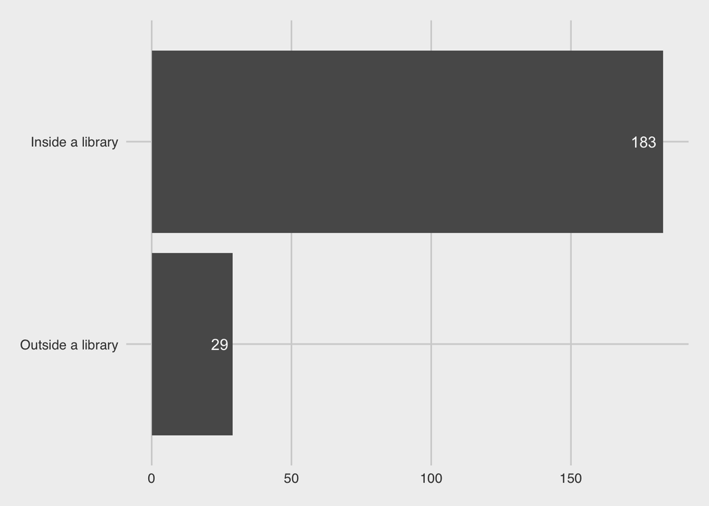

| id | Team | Session Name | Location | Locatioon Group | Category | Content |
| --- | --- | --- | --- | --- | --- | --- |
| 87 | Sir Edmund Hillary Library (Papakura) | Plunket Playgroup with Wriggle and Rhyme | Community library | Inside a library |  | wriggle &amp; rhyme |
| 88 | Botany Library | Wriggle and Rhyme | Community library | Inside a library |  | wriggle &amp; rhyme |
| 89 | Central City Library - Tāmaki Pātaka Kōrero | Heritage talk | Community library | Inside a library | Guest speaker | family history |
| 90 | Sir Edmund Hillary Library (Papakura) | Family History Help | Community library | Inside a library | Class or workshop | family history |
| 91 | Sir Edmund Hillary Library (Papakura) | Wriggle &amp; Rhyme | Community library | Inside a library |  | wriggle &amp; rhyme |
| 93 | Te Manawa (Westgate) | Family Day at Triangle Park | Community place/venue | Outside a library | Community event | engaging with the community |
| 96 | Sir Edmund Hillary Library (Papakura) | LEGO Steam | Community library | Inside a library | Class or workshop | using lego to explore engineering and architecture by applying stem principles |
| 102 | Warkworth Library | Make Give Live | Community place/venue | Outside a library | Class or workshop | arts &amp; craft |
| 103 | Warkworth Library | The Big Buzz Festival | Primary / intermediate school | Outside a library | Community event | environment &amp; sustainability |
| 104 | Te Manawa (Westgate) | Tai Chi | Community library | Inside a library | Class or workshop | health &amp; wellbeing |

[output cut: 202 more lines]

## Delivery group

How many sessions were co-delivered, how many were delivered by a library, and how many were delivered by an external?

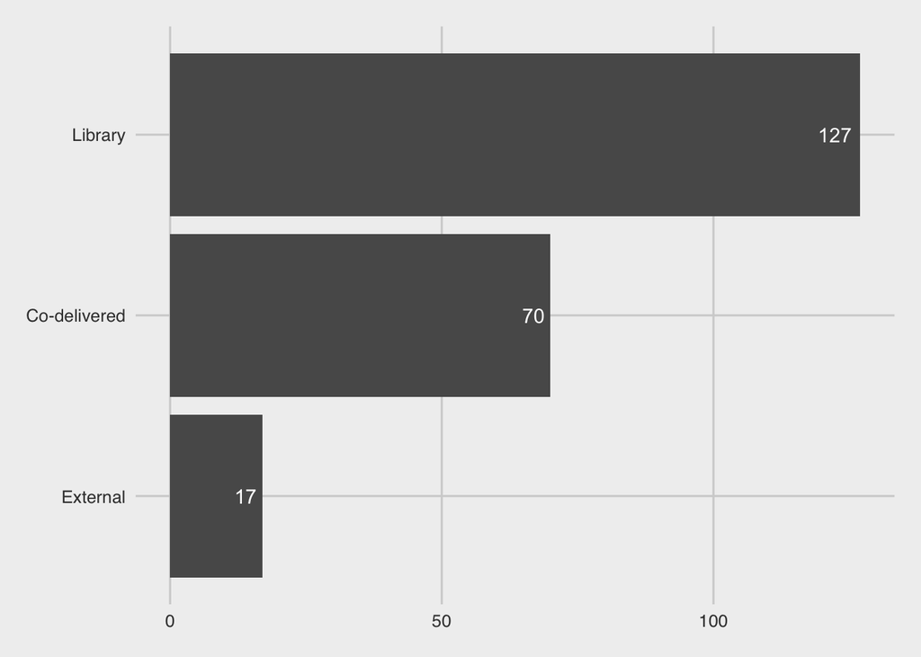

Of the sessions that were *not* co-delivered, how many were delivered by each delivery agent?

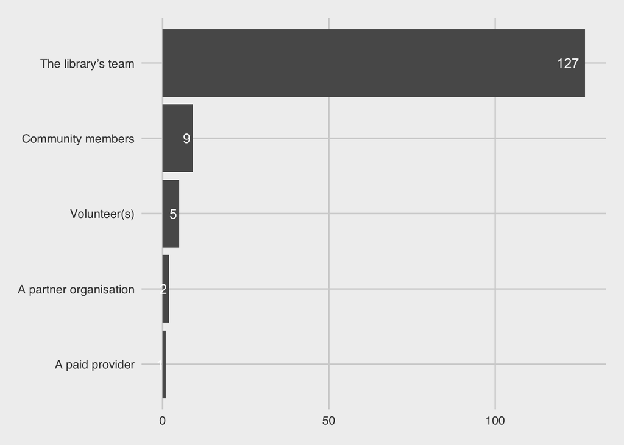

Of the sessions that *were* co-delivered, how many were delivered by each delivery agent?

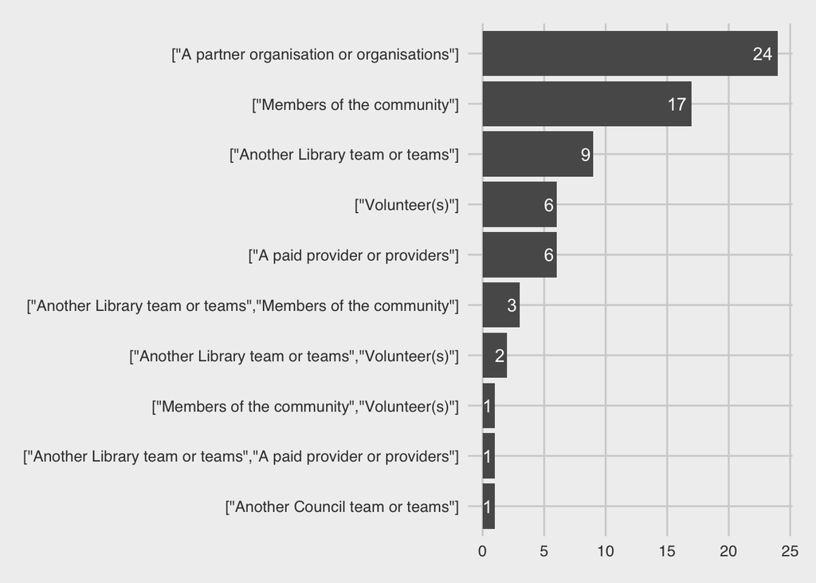

| id | Team | Session Name | Delivery agent | Co-delivery agents | Delivery Group | Category | Content |
| --- | --- | --- | --- | --- | --- | --- | --- |
| 87 | Sir Edmund Hillary Library (Papakura) | Plunket Playgroup with Wriggle and Rhyme |  | ["A partner organisation or organisations"] | Co-delivered |  | wriggle &amp; rhyme |
| 88 | Botany Library | Wriggle and Rhyme | The library’s team |  | Library |  | wriggle &amp; rhyme |
| 89 | Central City Library - Tāmaki Pātaka Kōrero | Heritage talk |  | ["Another Library team or teams"] | Co-delivered | Guest speaker | family history |
| 90 | Sir Edmund Hillary Library (Papakura) | Family History Help |  | ["A partner organisation or organisations"] | Co-delivered | Class or workshop | family history |
| 91 | Sir Edmund Hillary Library (Papakura) | Wriggle &amp; Rhyme | The library’s team |  | Library |  | wriggle &amp; rhyme |
| 93 | Te Manawa (Westgate) | Family Day at Triangle Park |  | ["Another Library team or teams","A paid provider or providers"] | Co-delivered | Community event | engaging with the community |
| 96 | Sir Edmund Hillary Library (Papakura) | LEGO Steam |  | ["A partner organisation or organisations"] | Co-delivered | Class or workshop | using lego to explore engineering and architecture by applying stem principles |
| 102 | Warkworth Library | Make Give Live |  | ["Another Library team or teams","Members of the community"] | Co-delivered | Class or workshop | arts &amp; craft |
| 103 | Warkworth Library | The Big Buzz Festival |  | ["Members of the community"] | Co-delivered | Community event | environment &amp; sustainability |
| 104 | Te Manawa (Westgate) | Tai Chi | Community members |  | External | Class or workshop | health &amp; wellbeing |

[output cut: 204 more lines]

## Target audiences: Māori or Pasifika

Was the session designed to specifically benefit Māori or Pasifika?

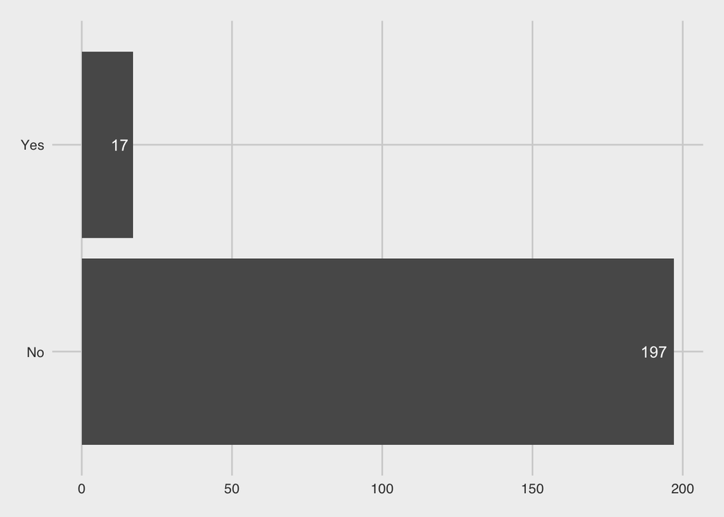

Which community was the session designed to specifically benefit, Māori or Pasifika?

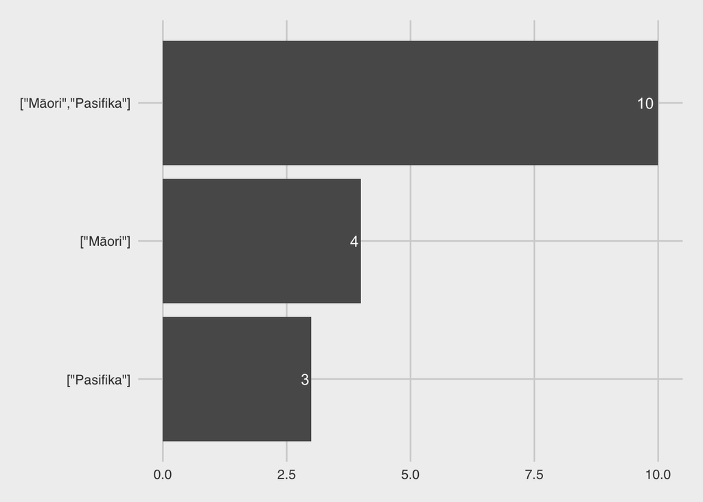

| id | Team | Session Name | Māori, Pasifika, or both? | Category | Content |
| --- | --- | --- | --- | --- | --- |
| 89 | Central City Library - Tāmaki Pātaka Kōrero | Heritage talk | ["Pasifika"] | Guest speaker | family history |
| 93 | Te Manawa (Westgate) | Family Day at Triangle Park | ["Māori","Pasifika"] | Community event | engaging with the community |
| 107 | Te Manawa (Westgate) | The Fono | ["Māori","Pasifika"] | Class or workshop | health &amp; wellbeing |
| 123 | Te Matariki Clendon Library | Kohanga Reo Outreach - Te Wiri | ["Māori"] |  | kohanga reo |
| 126 | Glenfield Library | Wriggle and Rhyme #3 | ["Māori"] |  | wriggle &amp; rhyme |
| 128 | Glenfield Library | RhymeTime - James | ["Māori"] |  | rhymetime |
| 132 | Glenfield Library | Business Seminar | ["Māori","Pasifika"] | Class or workshop | employment literacy |
| 136 | Glenfield Library | Work Navigator Drop-in | ["Māori","Pasifika"] | Class or workshop | employment literacy |
| 138 | Glenfield Library | Storytime at Active Explorers ECE | ["Māori","Pasifika"] |  | storytime |
| 172 | Research Central (Central City Library) | Heritage talk | ["Māori"] | Author talk | whakapapa/māori research |

[output cut: 7 more lines]

## Target audiences: other communities

Was the session designed to specifically benefit other communities?

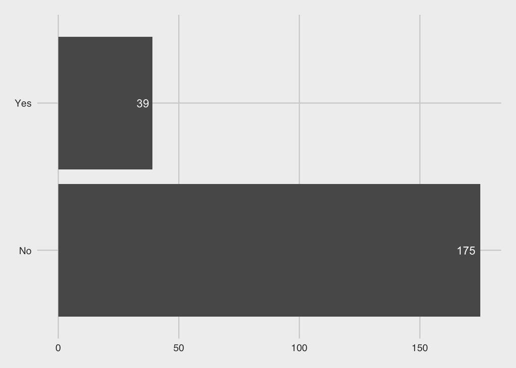

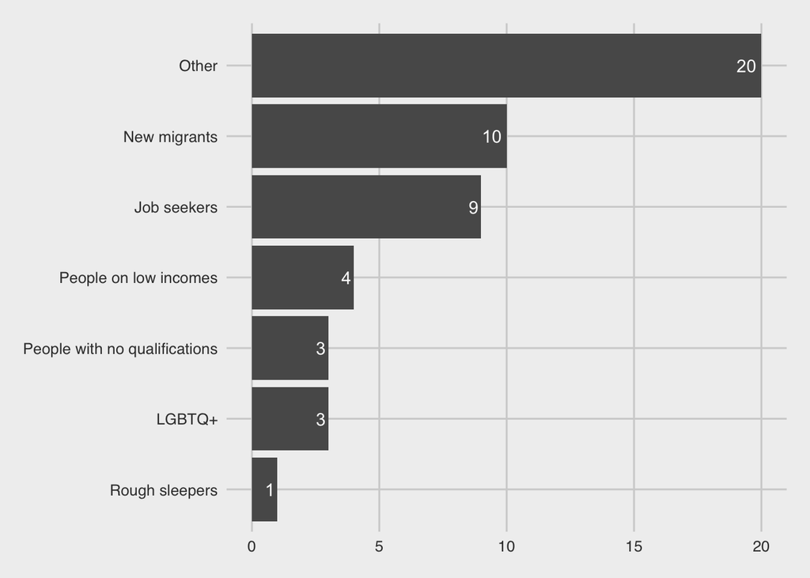

| id | Team | Session Name | Communities | Communities Other? | Category | Content |
| --- | --- | --- | --- | --- | --- | --- |
| 93 | Te Manawa (Westgate) | Family Day at Triangle Park | Families | Other | Community event | engaging with the community |
| 102 | Warkworth Library | Make Give Live | Connectedness | Other | Class or workshop | arts &amp; craft |
| 103 | Warkworth Library | The Big Buzz Festival | Families | Other | Community event | environment &amp; sustainability |
| 108 | Manukau Library | Mandarin computer class | Older (70-85 yrs)members of the Chinese community | Other | Class or workshop | digital literacy |
| 108 | Manukau Library | Mandarin computer class | New migrants | Selection | Class or workshop | digital literacy |
| 120 | Highland Park Library | English Lessons for Mandarin speakers | New migrants | Selection | Class or workshop | esol |
| 127 | Onehunga Library | Rhymetime | Chinese community | Other |  | rhymetime |
| 131 | Northcote Library | Bilingual Rhymetime | Chinese families | Other |  | rhymetime |
| 132 | Glenfield Library | Business Seminar | Job seekers | Selection | Class or workshop | employment literacy |
| 134 | Glenfield Library | Knit and Natter | The lonely | Other | Club | arts &amp; craft |

[output cut: 40 more lines]

## Target audiences: age groups

Was the session designed to specifically benefit a target age group?

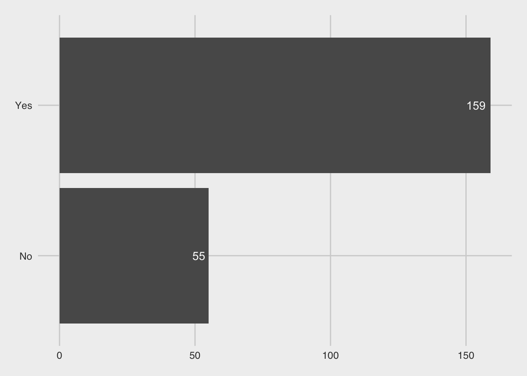

What was the target age group for the session?

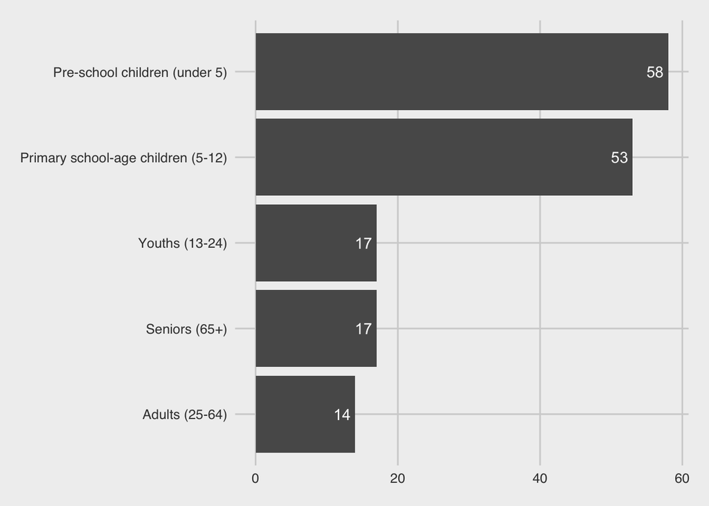

| id | Team | Session Name | Age group | Category | Content |
| --- | --- | --- | --- | --- | --- |
| 87 | Sir Edmund Hillary Library (Papakura) | Plunket Playgroup with Wriggle and Rhyme | Pre-school children (under 5) |  | wriggle &amp; rhyme |
| 88 | Botany Library | Wriggle and Rhyme | Pre-school children (under 5) |  | wriggle &amp; rhyme |
| 89 | Central City Library - Tāmaki Pātaka Kōrero | Heritage talk | None | Guest speaker | family history |
| 90 | Sir Edmund Hillary Library (Papakura) | Family History Help | None | Class or workshop | family history |
| 91 | Sir Edmund Hillary Library (Papakura) | Wriggle &amp; Rhyme | Pre-school children (under 5) |  | wriggle &amp; rhyme |
| 93 | Te Manawa (Westgate) | Family Day at Triangle Park | Primary school-age children (5-12) | Community event | engaging with the community |
| 96 | Sir Edmund Hillary Library (Papakura) | LEGO Steam | Primary school-age children (5-12) | Class or workshop | using lego to explore engineering and architecture by applying stem principles |
| 102 | Warkworth Library | Make Give Live | None | Class or workshop | arts &amp; craft |
| 103 | Warkworth Library | The Big Buzz Festival | None | Community event | environment &amp; sustainability |
| 104 | Te Manawa (Westgate) | Tai Chi | Seniors (65+) | Class or workshop | health &amp; wellbeing |

[output cut: 204 more lines]

## Categories and Content

How would you categorise this session?

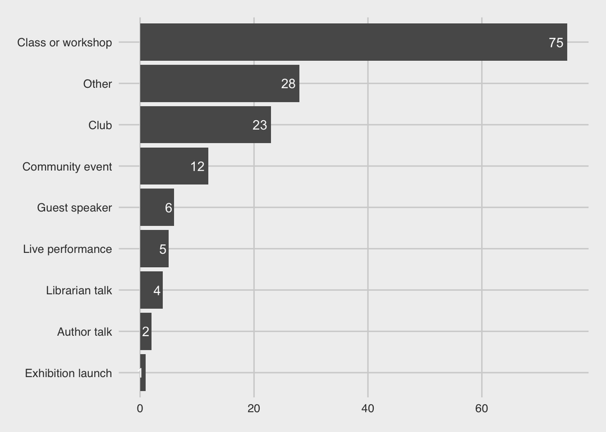

What was the primary focus or content of this session?

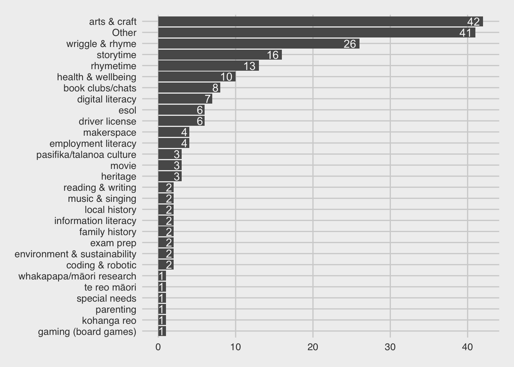

| id | Team | Session Name | Category Other? | Category | Content Other? | Content |
| --- | --- | --- | --- | --- | --- | --- |
| 89 | Central City Library - Tāmaki Pātaka Kōrero | Heritage talk | Selection | Guest speaker | Selection | family history |
| 90 | Sir Edmund Hillary Library (Papakura) | Family History Help | Selection | Class or workshop | Selection | family history |
| 93 | Te Manawa (Westgate) | Family Day at Triangle Park | Selection | Community event | Other | engaging with the community |
| 96 | Sir Edmund Hillary Library (Papakura) | LEGO Steam | Selection | Class or workshop | Other | using lego to explore engineering and architecture by applying stem principles |
| 102 | Warkworth Library | Make Give Live | Selection | Class or workshop | Selection | arts &amp; craft |
| 103 | Warkworth Library | The Big Buzz Festival | Selection | Community event | Selection | environment &amp; sustainability |
| 104 | Te Manawa (Westgate) | Tai Chi | Selection | Class or workshop | Selection | health &amp; wellbeing |
| 105 | Te Manawa (Westgate) | Caffeine &amp; Craft | Selection | Class or workshop | Selection | arts &amp; craft |
| 106 | Te Manawa (Westgate) | Good Friends Group | Selection | Club | Selection | health &amp; wellbeing |
| 107 | Te Manawa (Westgate) | The Fono | Selection | Class or workshop | Selection | health &amp; wellbeing |

[output cut: 146 more lines]

## Outreach

Was the session designed for and delivered to people that would not usually come to the library or community hub?

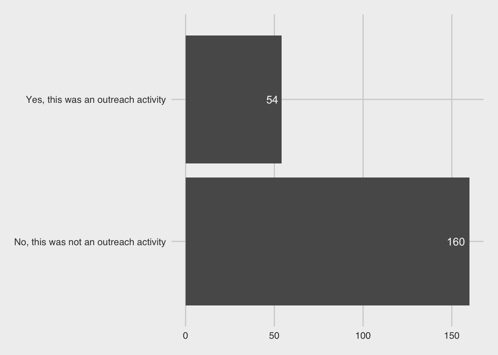

| id | Team | Session Name | Location | Location group |
| --- | --- | --- | --- | --- |
| 93 | Te Manawa (Westgate) | Family Day at Triangle Park | Triangle Park | Outside a library |
| 102 | Warkworth Library | Make Give Live | Old Masonic Hall Warkworth | Outside a library |
| 103 | Warkworth Library | The Big Buzz Festival | Primary / intermediate school | Outside a library |
| 104 | Te Manawa (Westgate) | Tai Chi | Te Manawa (Westgate) | Inside a library |
| 105 | Te Manawa (Westgate) | Caffeine &amp; Craft | Te Manawa (Westgate) | Inside a library |
| 106 | Te Manawa (Westgate) | Good Friends Group | Te Manawa (Westgate) | Inside a library |
| 107 | Te Manawa (Westgate) | The Fono | Te Manawa (Westgate) | Inside a library |
| 108 | Manukau Library | Mandarin computer class | Manukau Library | Inside a library |
| 109 | Research West (Waitakere Library) | Presentation to Powley Village, Blockhouse Bay | Rest home / retirement village | Outside a library |
| 110 | Te Manawa (Westgate) | Beginners Korowai | Te Manawa (Westgate) | Inside a library |

[output cut: 44 more lines]